# Lending Club

## Project Description

For this project I am exploring publicly available data from LendingClub.com.  
Lending Club connects people who need money (borrowers) with people who have money (investors).  
Hopefully, as an investor you would want to invest in people who showed a profile of having a high probability of paying you back. We will try to create a model that will help predict this.

Check out more info on Lending Club on [Wikipedia](https://en.wikipedia.org/wiki/Lending_Club). Lending Club also had a [very interesting year in 2016](https://en.wikipedia.org/wiki/Lending_Club#2016).

This dataset is from before they went public.

I am using lending data from 2007-2010 and will try to classify and predict whether or not the borrower paid back their loan in full. You will analyze the data file provided.

## Import Libraries

```python
import warnings
warnings.filterwarnings("ignore")
```

```python
%config InlineBackend.figure_format ='retina'
RANDOM_STATE = 42
```

```python
import pandas as pd
import numpy as np
import matplotlib.pyplot as plt
import seaborn as sns

from sklearn import metrics
```

```python
import sklearn
sklearn.__version__
```

```
'1.0.2'
```

```python
pd.set_option('display.max_columns', 100)
```

## Reading the Dataset. Finding the Shape of the dataset

```python
loans = pd.read_csv('loans.csv')
```

```python
rows=len(loans.axes[0])
print("Rows:",rows)
columns = len(loans.axes[1])
print("Variables:" ,columns)
```

```
Rows: 2981
Variables: 14
```

```python
# Use the unique() method to find unique values in the column
unique_values = loans['not.fully.paid'].unique()
print(unique_values)
```

```
[0 1]
```

### Finding the proportion of people who did not paid fully back

```python
import pandas as pd

not_fully_paid_count = loans['not.fully.paid'].sum()
total_rows = len(loans)
proportion_not_fully_paid = (not_fully_paid_count) / (total_rows)

# Print the proportion
print("Proportion of people who did not fully pay back the loan:", proportion_not_fully_paid)
```

```
Proportion of people who did not fully pay back the loan: 0.4807111707480711
```

**Checking out the info(), head(), and describe() methods on loans**

```python
loans.info()
```

```
<class 'pandas.core.frame.DataFrame'>
RangeIndex: 2981 entries, 0 to 2980
Data columns (total 14 columns):
 #   Column             Non-Null Count  Dtype
---  ------             --------------  -----
 0   credit.policy      2981 non-null   int64
 1   purpose            2981 non-null   object
 2   int.rate           2981 non-null   float64
 3   installment        2981 non-null   float64
 4   log.annual.inc     2981 non-null   float64
 5   dti                2981 non-null   float64
 6   fico               2981 non-null   int64
 7   days.with.cr.line  2981 non-null   float64
 8   revol.bal          2981 non-null   int64
 9   revol.util         2981 non-null   float64
 10  inq.last.6mths     2981 non-null   int64
 11  delinq.2yrs        2981 non-null   int64
 12  pub.rec            2981 non-null   int64
 13  not.fully.paid     2981 non-null   int64
dtypes: float64(6), int64(7), object(1)
memory usage: 326.2+ KB
```

```python
loans.head()
```

|  | credit.policy | purpose | int.rate | installment | log.annual.inc | dti | fico | days.with.cr.line | revol.bal | revol.util | inq.last.6mths | delinq.2yrs | pub.rec | not.fully.paid |
| --- | --- | --- | --- | --- | --- | --- | --- | --- | --- | --- | --- | --- | --- | --- |
| 0 | 1 | debt_consolidation | 0.1183 | 231.94 | 10.348846 | 5.69 | 712 | 2460.958333 | 6955 | 63.8 | 1 | 0 | 0 | 0 |
| 1 | 1 | major_purchase | 0.0774 | 124.88 | 11.264464 | 7.17 | 792 | 6360.041667 | 168 | 0.7 | 0 | 0 | 0 | 0 |
| 2 | 1 | credit_card | 0.1505 | 86.73 | 11.184421 | 16.30 | 667 | 3600.000000 | 16242 | 95.5 | 0 | 0 | 0 | 0 |
| 3 | 1 | debt_consolidation | 0.1284 | 403.42 | 10.736397 | 19.57 | 697 | 3450.041667 | 27261 | 87.4 | 1 | 0 | 0 | 0 |
| 4 | 1 | debt_consolidation | 0.1531 | 278.53 | 10.621327 | 8.20 | 662 | 1860.000000 | 7979 | 48.7 | 0 | 1 | 0 | 0 |

```python
loans.describe()
```

|  | credit.policy | int.rate | installment | log.annual.inc | dti | fico | days.with.cr.line | revol.bal | revol.util | inq.last.6mths | delinq.2yrs | pub.rec | not.fully.paid |
| --- | --- | --- | --- | --- | --- | --- | --- | --- | --- | --- | --- | --- | --- |
| count | 2981.000000 | 2981.000000 | 2981.000000 | 2981.000000 | 2981.000000 | 2981.000000 | 2981.000000 | 2.981000e+03 | 2981.000000 | 2981.000000 | 2981.000000 | 2981.000000 | 2981.000000 |
| mean | 0.748071 | 0.125977 | 326.020778 | 10.898762 | 12.794119 | 705.839316 | 4460.703008 | 1.826035e+04 | 48.442170 | 1.868165 | 0.171419 | 0.073465 | 0.480711 |
| std | 0.434193 | 0.026565 | 213.108504 | 0.650773 | 6.986455 | 37.073906 | 2486.531742 | 4.029009e+04 | 29.251287 | 2.567033 | 0.526928 | 0.271035 | 0.499712 |
| min | 0.000000 | 0.060000 | 15.670000 | 7.547502 | 0.000000 | 612.000000 | 180.041667 | 0.000000e+00 | 0.000000 | 0.000000 | 0.000000 | 0.000000 | 0.000000 |
| 25% | 0.000000 | 0.109600 | 165.630000 | 10.498250 | 7.170000 | 677.000000 | 2760.041667 | 2.979000e+03 | 24.700000 | 0.000000 | 0.000000 | 0.000000 | 0.000000 |
| 50% | 1.000000 | 0.125300 | 275.570000 | 10.915088 | 12.870000 | 702.000000 | 4043.000000 | 8.493000e+03 | 48.800000 | 1.000000 | 0.000000 | 0.000000 | 0.000000 |
| 75% | 1.000000 | 0.142600 | 457.050000 | 11.289782 | 18.350000 | 732.000000 | 5640.041667 | 1.853800e+04 | 72.500000 | 3.000000 | 0.000000 | 0.000000 | 1.000000 |
| max | 1.000000 | 0.216400 | 926.830000 | 14.124465 | 29.960000 | 817.000000 | 17616.000000 | 1.207359e+06 | 119.000000 | 33.000000 | 6.000000 | 3.000000 | 1.000000 |

## Exploratory Data Analysis

**Creating a histogram of two FICO distributions on top of each other, one for each credit.policy outcome.**

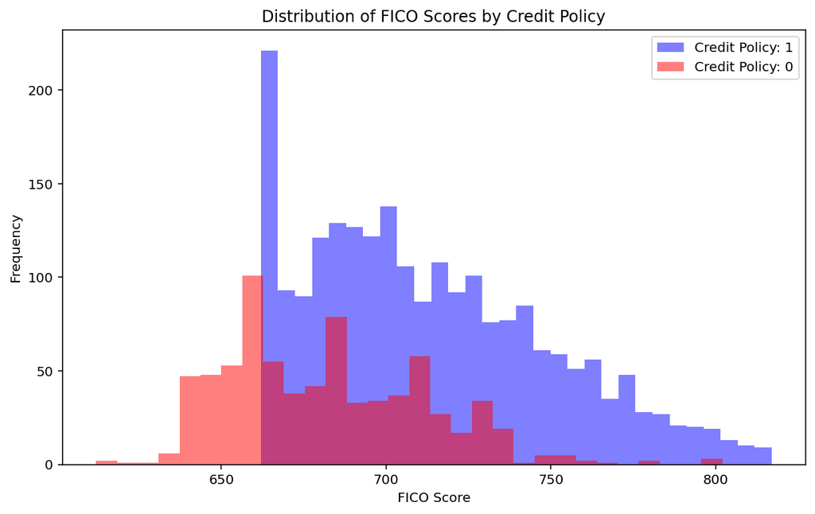

```python
import pandas as pd
import matplotlib.pyplot as plt

# Assuming you have a DataFrame named 'df' with columns 'FICO' and 'credit.policy'

# Separate FICO scores based on credit.policy outcome
fico_1 = loans[loans['credit.policy'] == 1]['fico']
fico_0 = loans[loans['credit.policy'] == 0]['fico']

# Set up the histogram
plt.figure(figsize=(10, 6))

# Plot histogram for credit.policy == 1
plt.hist(fico_1, bins=30, alpha=0.5, color='blue', label='Credit Policy: 1')

# Plot histogram for credit.policy == 0
plt.hist(fico_0, bins=30, alpha=0.5, color='red', label='Credit Policy: 0')

# Add labels and title
plt.xlabel('FICO Score')
plt.ylabel('Frequency')
plt.title('Distribution of FICO Scores by Credit Policy')
plt.legend()

# Show plot
plt.show()
```

**Creating a countplot (bar plot showing counts using seaborn) that shows the counts of loans by purpose, with the color hue defined by `not.fully.paid`**

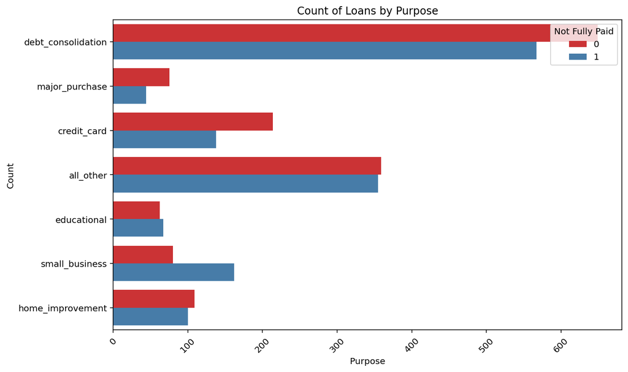

```python
import seaborn as sns
import matplotlib.pyplot as plt

loans.head()

# Plot the countplot
plt.figure(figsize=(10, 6))
data1 = loans['not.fully.paid']
data2 = loans['purpose']
sns.countplot(y='purpose', hue='not.fully.paid', data=loans, palette='Set1')
plt.title('Count of Loans by Purpose')
plt.xlabel('Purpose')
plt.ylabel('Count')
plt.xticks(rotation=45)  # Rotate x-axis labels for better readability
plt.legend(title='Not Fully Paid', loc='upper right')
plt.tight_layout()
plt.show()
```

**Creating the lmplots to see if the trend differed between `not.fully.paid` and `int.rate`**.

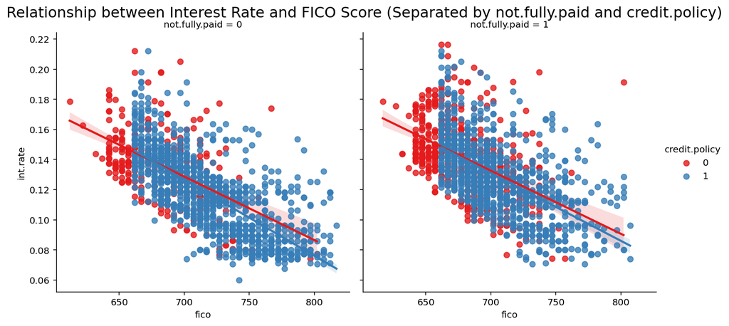

```python
import seaborn as sns
import matplotlib.pyplot as plt


sns.lmplot(x='fico', y='int.rate', data=loans, hue='credit.policy', col='not.fully.paid', palette='Set1', col_wrap=2)

# Set the title
plt.subplots_adjust(top=0.9)  # Adjust the position of the title
plt.suptitle('Relationship between Interest Rate and FICO Score (Separated by not.fully.paid and credit.policy)', fontsize=16)

# Show the plot
plt.show()
```

**we noticed that `purpose` column from dataset is a categorical. we have to transform that column in to numerical type using dummy variables**

```python
cat_feats = ['purpose']
```

```python
loans = pd.get_dummies(loans, columns=cat_feats, drop_first=False)
```

```python
loans.info()
```

```
<class 'pandas.core.frame.DataFrame'>
RangeIndex: 2981 entries, 0 to 2980
Data columns (total 20 columns):
 #   Column                      Non-Null Count  Dtype
---  ------                      --------------  -----
 0   credit.policy               2981 non-null   int64
 1   int.rate                    2981 non-null   float64
 2   installment                 2981 non-null   float64
 3   log.annual.inc              2981 non-null   float64
 4   dti                         2981 non-null   float64
 5   fico                        2981 non-null   int64
 6   days.with.cr.line           2981 non-null   float64
 7   revol.bal                   2981 non-null   int64
 8   revol.util                  2981 non-null   float64
 9   inq.last.6mths              2981 non-null   int64
 10  delinq.2yrs                 2981 non-null   int64
 11  pub.rec                     2981 non-null   int64
 12  not.fully.paid              2981 non-null   int64
 13  purpose_all_other           2981 non-null   bool
 14  purpose_credit_card         2981 non-null   bool
 15  purpose_debt_consolidation  2981 non-null   bool
 16  purpose_educational         2981 non-null   bool
 17  purpose_home_improvement    2981 non-null   bool
 18  purpose_major_purchase      2981 non-null   bool
 19  purpose_small_business      2981 non-null   bool
dtypes: bool(7), float64(6), int64(7)
memory usage: 323.3 KB
```

```python
loans.head()
```

|  | credit.policy | int.rate | installment | log.annual.inc | dti | fico | days.with.cr.line | revol.bal | revol.util | inq.last.6mths | delinq.2yrs | pub.rec | not.fully.paid | purpose_all_other | purpose_credit_card | purpose_debt_consolidation | purpose_educational | purpose_home_improvement | purpose_major_purchase | purpose_small_business |
| --- | --- | --- | --- | --- | --- | --- | --- | --- | --- | --- | --- | --- | --- | --- | --- | --- | --- | --- | --- | --- |
| 0 | 1 | 0.1183 | 231.94 | 10.348846 | 5.69 | 712 | 2460.958333 | 6955 | 63.8 | 1 | 0 | 0 | 0 | False | False | True | False | False | False | False |
| 1 | 1 | 0.0774 | 124.88 | 11.264464 | 7.17 | 792 | 6360.041667 | 168 | 0.7 | 0 | 0 | 0 | 0 | False | False | False | False | False | True | False |
| 2 | 1 | 0.1505 | 86.73 | 11.184421 | 16.30 | 667 | 3600.000000 | 16242 | 95.5 | 0 | 0 | 0 | 0 | False | True | False | False | False | False | False |
| 3 | 1 | 0.1284 | 403.42 | 10.736397 | 19.57 | 697 | 3450.041667 | 27261 | 87.4 | 1 | 0 | 0 | 0 | False | False | True | False | False | False | False |
| 4 | 1 | 0.1531 | 278.53 | 10.621327 | 8.20 | 662 | 1860.000000 | 7979 | 48.7 | 0 | 1 | 0 | 0 | False | False | True | False | False | False | False |

## Train Test Split

The not fully paid column is the target column. We are droping that column. Spliting the remaining dataset in to train and test.

```python
from sklearn.model_selection import train_test_split
```

```python
loans
```

|  | credit.policy | int.rate | installment | log.annual.inc | dti | fico | days.with.cr.line | revol.bal | revol.util | inq.last.6mths | delinq.2yrs | pub.rec | not.fully.paid | purpose_all_other | purpose_credit_card | purpose_debt_consolidation | purpose_educational | purpose_home_improvement | purpose_major_purchase | purpose_small_business |
| --- | --- | --- | --- | --- | --- | --- | --- | --- | --- | --- | --- | --- | --- | --- | --- | --- | --- | --- | --- | --- |
| 0 | 1 | 0.1183 | 231.94 | 10.348846 | 5.69 | 712 | 2460.958333 | 6955 | 63.8 | 1 | 0 | 0 | 0 | False | False | True | False | False | False | False |
| 1 | 1 | 0.0774 | 124.88 | 11.264464 | 7.17 | 792 | 6360.041667 | 168 | 0.7 | 0 | 0 | 0 | 0 | False | False | False | False | False | True | False |
| 2 | 1 | 0.1505 | 86.73 | 11.184421 | 16.30 | 667 | 3600.000000 | 16242 | 95.5 | 0 | 0 | 0 | 0 | False | True | False | False | False | False | False |
| 3 | 1 | 0.1284 | 403.42 | 10.736397 | 19.57 | 697 | 3450.041667 | 27261 | 87.4 | 1 | 0 | 0 | 0 | False | False | True | False | False | False | False |
| 4 | 1 | 0.1531 | 278.53 | 10.621327 | 8.20 | 662 | 1860.000000 | 7979 | 48.7 | 0 | 1 | 0 | 0 | False | False | True | False | False | False | False |
| ... | ... | ... | ... | ... | ... | ... | ... | ... | ... | ... | ... | ... | ... | ... | ... | ... | ... | ... | ... | ... |
| 2976 | 0 | 0.1797 | 364.99 | 10.762488 | 23.53 | 642 | 4252.041667 | 10226 | 63.9 | 1 | 1 | 0 | 0 | False | False | True | False | False | False | False |
| 2977 | 1 | 0.1316 | 202.63 | 11.156251 | 23.91 | 692 | 2130.000000 | 22713 | 43.1 | 1 | 0 | 0 | 0 | False | False | True | False | False | False | False |
| 2978 | 1 | 0.1148 | 263.75 | 10.491274 | 2.90 | 727 | 1800.000000 | 2980 | 31.7 | 1 | 0 | 0 | 0 | False | False | True | False | False | False | False |
| 2979 | 1 | 0.1442 | 859.57 | 12.611538 | 1.48 | 702 | 5279.958333 | 28367 | 66.5 | 2 | 1 | 0 | 0 | False | False | False | False | True | False | False |
| 2980 | 1 | 0.0894 | 381.26 | 11.512925 | 11.27 | 747 | 4649.958333 | 23270 | 41.0 | 1 | 0 | 0 | 0 | False | False | False | False | False | True | False |

2981 rows × 20 columns

```python
X = loans.drop('not.fully.paid',axis=1)
y = loans['not.fully.paid']
X_train, X_test, y_train, y_test = train_test_split(X, y, test_size=0.40, random_state=RANDOM_STATE)
X_val, X_test, y_val, y_test = train_test_split(X_test, y_test, test_size=0.50, random_state=RANDOM_STATE)
```

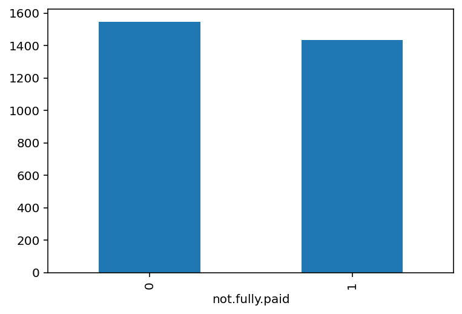

```python
y.value_counts().plot(kind='bar')
```

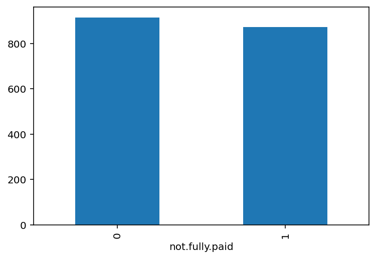

```python
y_train.value_counts().plot(kind='bar')
```

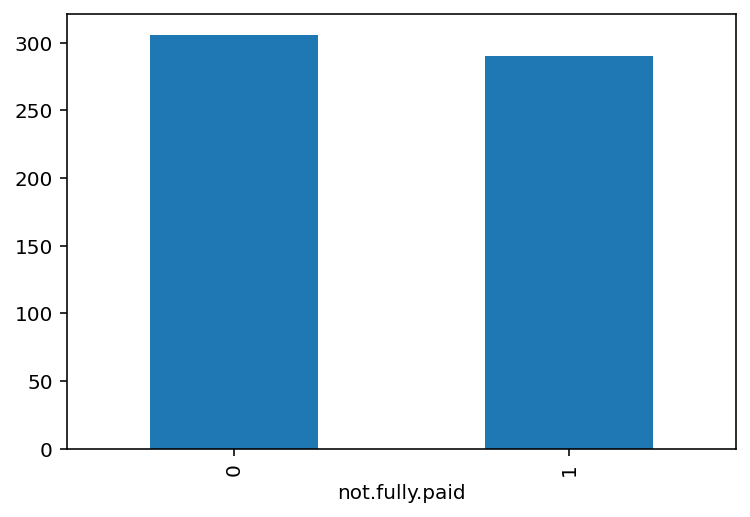

```python
y_val.value_counts().plot(kind='bar')
```

## Decision Tree Model

Implementing the model . Finding Accuracies for both train and validation

```python
# Import DecisionTreeClassifier
from sklearn.tree import DecisionTreeClassifier
```

```python
from sklearn.tree import DecisionTreeClassifier
from sklearn.metrics import accuracy_score, confusion_matrix, classification_report,balanced_accuracy_score

# Initiate the Decision Tree classifier with default parameters
clf = DecisionTreeClassifier()

# Fit the model on the training data
clf.fit(X_train, y_train)

# Make predictions on the training and validation sets
y_train_pred = clf.predict(X_test)
y_val_pred = clf.predict(X_val)
#print(len(X_test))
# Calculate accuracy score for training and validation sets
train_accuracy = accuracy_score(y_test, y_train_pred)
val_accuracy = accuracy_score(y_val, y_val_pred)

print("Training Accuracy:", train_accuracy)
print("Validation Accuracy:", val_accuracy)

# Create confusion matrix for validation set
conf_matrix = confusion_matrix(y_val, y_val_pred)
print("Confusion Matrix:")
print(conf_matrix)

# Provide performance metrics for the validation set
#print("Classification Report:")
#print(classification_report(y_test, y_val_pred))
from sklearn.metrics import classification_report

# Get the classification report
report = classification_report(y_val, y_val_pred, output_dict=True)

# Extract precision, recall, and F1-score for each class
precision = report['macro avg']['precision']
recall = report['macro avg']['recall']
f1_score = report['macro avg']['f1-score']
tn = conf_matrix[0][0]
fn = conf_matrix[1][0]
specificity = tn / (tn+fn)
balance = balanced_accuracy_score(y_val, y_val_pred)

print("Precision:", precision)
print("Recall:", recall)
print("F1-score:", f1_score)
print("specificity",specificity)
print("balanced accuracy",balance)
```

```
Training Accuracy: 0.5577889447236181
Validation Accuracy: 0.5704697986577181
Confusion Matrix:
[[170 136]
 [120 170]]
Precision: 0.5708812260536398
Recall: 0.5708812260536398
F1-score: 0.5704697986577182
specificity 0.5862068965517241
balanced accuracy 0.5708812260536398
```

i) Using the training data perform hyper-parameter tuning.

ii) Trying with several values for the `min_samples_split` hyper-parameter and applying cross validation (`GridSearchCV`) to finding the best value.

iii) Using the best model to provide the performance metrics for the validation set.

iv) Trying several values for the `max_depth` hyper-parameter and applying cross validation (`GridSearchCV`) to finding the best value.

v) Using the best model provide the performance metrics for the validation set.

vi) Performing grid search (`GridSearchCV`) to check `min_samples_split` and `max_depth`.

vii) Using the best model provide the performance metrics for the validation set.

```python
from sklearn.model_selection import GridSearchCV

# Hyperparameter tuning for min_samples_split
param_grid = {'min_samples_split': [2, 5, 10, 15, 20]}

grid_search_min_samples_split = GridSearchCV(DecisionTreeClassifier(), param_grid, scoring='f1', cv=5)
grid_search_min_samples_split.fit(X_train, y_train)

print("Best min_samples_split:", grid_search_min_samples_split.best_params_)

# Evaluate the best model's performance on the validation set
best_clf_min_samples_split = grid_search_min_samples_split.best_estimator_
y_pred_val_min_samples_split = best_clf_min_samples_split.predict(X_val)

print("Performance metrics for min_samples_split:")
print(classification_report(y_val, y_pred_val_min_samples_split))

# Hyperparameter tuning for max_depth
param_grid = {'max_depth': [None, 5, 10, 15, 20]}

grid_search_max_depth = GridSearchCV(DecisionTreeClassifier(), param_grid, scoring='f1', cv=5)
grid_search_max_depth.fit(X_train, y_train)

print("Best max_depth:", grid_search_max_depth.best_params_)

# Evaluate the best model's performance on the validation set
best_clf_max_depth = grid_search_max_depth.best_estimator_
y_pred_val_max_depth = best_clf_max_depth.predict(X_val)

print("Performance metrics for max_depth:")
print(classification_report(y_val, y_pred_val_max_depth))

# Perform grid search for both min_samples_split and max_depth
param_grid = {'min_samples_split': [2, 5, 10, 15, 20],
              'max_depth': [None, 5, 10, 15, 20]}

grid_search = GridSearchCV(DecisionTreeClassifier(), param_grid, scoring='f1', cv=5)
grid_search.fit(X_train, y_train)

print("Best parameters:", grid_search.best_params_)

# Evaluate the best model's performance on the validation set
best_clf = grid_search.best_estimator_
y_pred_val = best_clf.predict(X_val)

print("Performance metrics for the best model:")
print(classification_report(y_val, y_pred_val))
```

```
Best min_samples_split: {'min_samples_split': 5}
Performance metrics for min_samples_split:
              precision    recall  f1-score   support

           0       0.58      0.57      0.58       306
           1       0.56      0.57      0.56       290

    accuracy                           0.57       596
   macro avg       0.57      0.57      0.57       596
weighted avg       0.57      0.57      0.57       596

Best max_depth: {'max_depth': 5}
Performance metrics for max_depth:
              precision    recall  f1-score   support

           0       0.58      0.68      0.62       306
           1       0.59      0.48      0.53       290

    accuracy                           0.58       596
   macro avg       0.58      0.58      0.58       596
weighted avg       0.58      0.58      0.58       596

Best parameters: {'max_depth': 5, 'min_samples_split': 20}
Performance metrics for the best model:
              precision    recall  f1-score   support

           0       0.58      0.68      0.63       306
           1       0.59      0.48      0.53       290

    accuracy                           0.58       596
   macro avg       0.58      0.58      0.58       596
weighted avg       0.58      0.58      0.58       596
```

**A chart showing the feature importances based on the best model obtained.**

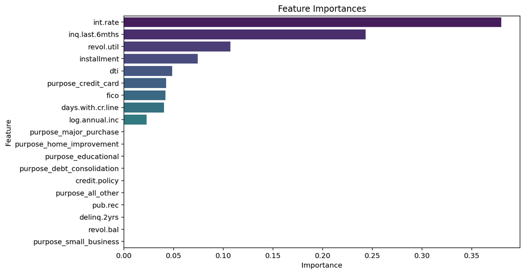

```python
import matplotlib.pyplot as plt
import seaborn as sns

# Get the feature names and importances from the best model
feature_names = X.columns.tolist()
feature_importances = best_clf.feature_importances_

# Ensure that the lengths of both arrays are the same
if len(feature_names) != len(feature_importances):
    raise ValueError("The number of feature names and feature importances must be the same.")

# Create a DataFrame for visualization
importance_df = pd.DataFrame({'Feature': feature_names, 'Importance': feature_importances})

# Sort the DataFrame by feature importance
importance_df = importance_df.sort_values(by='Importance', ascending=False)

# Plot the feature importances
plt.figure(figsize=(10, 6))
sns.barplot(x='Importance', y='Feature', data=importance_df, palette='viridis')
plt.title('Feature Importances')
plt.xlabel('Importance')
plt.ylabel('Feature')
plt.show()
```

## Random Forest model

Implementing the model. Finding accuracies for both train and validation dataset.

```python
from sklearn.ensemble import RandomForestClassifier
```

```python
from sklearn.metrics import accuracy_score, confusion_matrix, classification_report,balanced_accuracy_score

# Initiate the Decision Tree classifier with default parameters
clf = RandomForestClassifier()

# Fit the model on the training data
clf.fit(X_train, y_train)

# Make predictions on the training and validation sets
y_train_pred = clf.predict(X_test)
y_val_pred = clf.predict(X_val)
#print(len(X_test))
# Calculate accuracy score for training and validation sets
train_accuracy = accuracy_score(y_test, y_train_pred)
val_accuracy = accuracy_score(y_val, y_val_pred)

print("Training Accuracy:", train_accuracy)
print("Validation Accuracy:", val_accuracy)

# Create confusion matrix for validation set
conf_matrix = confusion_matrix(y_val, y_val_pred)
print("Confusion Matrix:")
print(conf_matrix)

# Provide performance metrics for the validation set
#print("Classification Report:")
#print(classification_report(y_test, y_val_pred))
from sklearn.metrics import classification_report

# Get the classification report
report = classification_report(y_val, y_val_pred, output_dict=True)

# Extract precision, recall, and F1-score for each class
precision = report['macro avg']['precision']
recall = report['macro avg']['recall']
f1_score = report['macro avg']['f1-score']
tn = conf_matrix[0][0]
fn = conf_matrix[1][0]
specificity = tn / (tn+fn)
balance = balanced_accuracy_score(y_val, y_val_pred)

print("Precision:", precision)
print("Recall:", recall)
print("F1-score:", f1_score)
print("specificity",specificity)
print("balanced accuracy",balance)
```

```
Training Accuracy: 0.5896147403685092
Validation Accuracy: 0.6057046979865772
Confusion Matrix:
[[191 115]
 [120 170]]
Precision: 0.6053195690190105
Recall: 0.605194951543836
F1-score: 0.6052145726164471
specificity 0.6141479099678456
balanced accuracy 0.605194951543836
```

Using the training data perform hyper-parameter tuning.

- Perform grid search (`GridSearchCV`) where you check for `min_samples_split`, `max_depth`, and `n_estimators`.
- Using the best model provide the performance metrics for the validation set.

```python
from sklearn.model_selection import GridSearchCV
from sklearn.ensemble import RandomForestClassifier
from sklearn.metrics import classification_report

# Define the parameter grid
param_grid = {
    'min_samples_split': [2, 5, 10],
    'max_depth': [None, 5, 10, 20],
    'n_estimators': [50, 100, 200]
}

# Initiate the Random Forest classifier
clf = RandomForestClassifier(random_state=42)

# Perform grid search
grid_search = GridSearchCV(clf, param_grid, scoring='f1', cv=5)
grid_search.fit(X_train, y_train)

# Get the best model
best_clf = grid_search.best_estimator_

# Make predictions on the validation set
y_val_pred = best_clf.predict(X_val)
print("Best parameters:", grid_search.best_params_)

# Calculate performance metrics for the validation set
print("Performance metrics for the best model:")
print(classification_report(y_val, y_val_pred))
```

```
Best parameters: {'max_depth': 10, 'min_samples_split': 10, 'n_estimators': 200}
Performance metrics for the best model:
              precision    recall  f1-score   support

           0       0.63      0.62      0.63       306
           1       0.61      0.62      0.62       290

    accuracy                           0.62       596
   macro avg       0.62      0.62      0.62       596
weighted avg       0.62      0.62      0.62       596
```

**A chart showing the feature importances based on the best model obtained.**

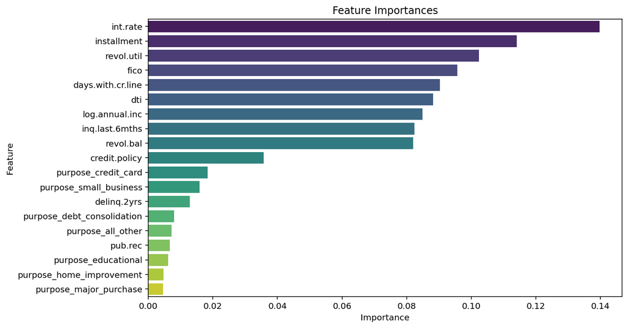

```python
import matplotlib.pyplot as plt
import seaborn as sns

# Get the feature names and importances from the best model
feature_names = X.columns.tolist()
feature_importances = best_clf.feature_importances_

# Ensure that the lengths of both arrays are the same
if len(feature_names) != len(feature_importances):
    raise ValueError("The number of feature names and feature importances must be the same.")

# Create a DataFrame for visualization
importance_df = pd.DataFrame({'Feature': feature_names, 'Importance': feature_importances})

# Sort the DataFrame by feature importance
importance_df = importance_df.sort_values(by='Importance', ascending=False)

# Plot the feature importances
plt.figure(figsize=(10, 6))
sns.barplot(x='Importance', y='Feature', data=importance_df, palette='viridis')
plt.title('Feature Importances')
plt.xlabel('Importance')
plt.ylabel('Feature')
plt.show()
```

## Adaboost model

Implementing the model. Finding Accuracies for both train and test models.

```python
from sklearn.ensemble import AdaBoostClassifier
```

```python
from sklearn.metrics import accuracy_score, confusion_matrix, classification_report,balanced_accuracy_score

# Initiate the Decision Tree classifier with default parameters
clf = AdaBoostClassifier()

# Fit the model on the training data
clf.fit(X_train, y_train)

# Make predictions on the training and validation sets
y_train_pred = clf.predict(X_test)
y_val_pred = clf.predict(X_val)
#print(len(X_test))
# Calculate accuracy score for training and validation sets
train_accuracy = accuracy_score(y_test, y_train_pred)
val_accuracy = accuracy_score(y_val, y_val_pred)

print("Training Accuracy:", train_accuracy)
print("Validation Accuracy:", val_accuracy)

# Create confusion matrix for validation set
conf_matrix = confusion_matrix(y_val, y_val_pred)
print("Confusion Matrix:")
print(conf_matrix)

# Provide performance metrics for the validation set
#print("Classification Report:")
#print(classification_report(y_test, y_val_pred))
from sklearn.metrics import classification_report

# Get the classification report
report = classification_report(y_val, y_val_pred, output_dict=True)

# Extract precision, recall, and F1-score for each class
precision = report['macro avg']['precision']
recall = report['macro avg']['recall']
f1_score = report['macro avg']['f1-score']
tn = conf_matrix[0][0]
fn = conf_matrix[1][0]
specificity = tn / (tn+fn)
balance = balanced_accuracy_score(y_val, y_val_pred)

print("Precision:", precision)
print("Recall:", recall)
print("F1-score:", f1_score)
print("specificity",specificity)
print("balanced accuracy",balance)
```

```
Training Accuracy: 0.5979899497487438
Validation Accuracy: 0.5855704697986577
Confusion Matrix:
[[177 129]
 [118 172]]
Precision: 0.5857142857142856
Recall: 0.5857674104124408
F1-score: 0.5855413003144787
specificity 0.6
balanced accuracy 0.5857674104124408
```

Using the training data perform hyper-parameter tuning.

- Perform grid search (`GridSearchCV`) where you check for `learning_rate`, and `n_estimators`.
- Using the best model provide the performance metrics for the validation set.

```python
from sklearn.model_selection import GridSearchCV
from sklearn.ensemble import AdaBoostClassifier
from sklearn.metrics import classification_report

# Define the parameter grid
param_grid = {
    'learning_rate': [0.1, 0.5, 1.0],
    'n_estimators': [50, 100, 200]
}

# Initiate the AdaBoost classifier
clf = AdaBoostClassifier()

# Perform grid search
grid_search = GridSearchCV(clf, param_grid, scoring='f1', cv=5)
grid_search.fit(X_train, y_train)

# Get the best model
best_clf = grid_search.best_estimator_

# Make predictions on the validation set
y_val_pred = best_clf.predict(X_val)
print("Best parameters:", grid_search.best_params_)

# Calculate performance metrics for the validation set
print("Performance metrics for the best model:")
print(classification_report(y_val, y_val_pred))
```

```
Best parameters: {'learning_rate': 0.1, 'n_estimators': 200}
Performance metrics for the best model:
              precision    recall  f1-score   support

           0       0.61      0.62      0.61       306
           1       0.59      0.58      0.59       290

    accuracy                           0.60       596
   macro avg       0.60      0.60      0.60       596
weighted avg       0.60      0.60      0.60       596
```

**A chart showing the feature importances based on the best model obtained.**

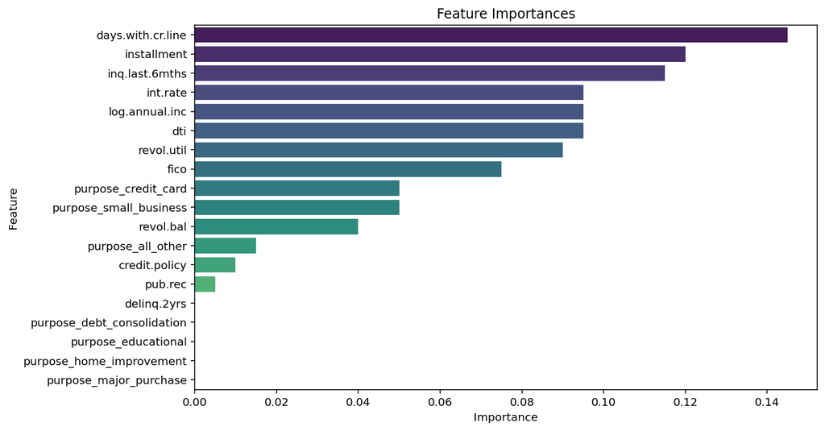

```python
import matplotlib.pyplot as plt
import seaborn as sns

# Get the feature names and importances from the best model
feature_names = X.columns.tolist()
feature_importances = best_clf.feature_importances_

# Ensure that the lengths of both arrays are the same
if len(feature_names) != len(feature_importances):
    raise ValueError("The number of feature names and feature importances must be the same.")

# Create a DataFrame for visualization
importance_df = pd.DataFrame({'Feature': feature_names, 'Importance': feature_importances})

# Sort the DataFrame by feature importance
importance_df = importance_df.sort_values(by='Importance', ascending=False)

# Plot the feature importances
plt.figure(figsize=(10, 6))
sns.barplot(x='Importance', y='Feature', data=importance_df, palette='viridis')
plt.title('Feature Importances')
plt.xlabel('Importance')
plt.ylabel('Feature')
plt.show()
```

## Gradient Boosting Machine

Implementing the Model.Finding Accuracies for both training and validation set.

```python
from sklearn.ensemble import GradientBoostingClassifier
```

```python
from sklearn.metrics import accuracy_score, confusion_matrix, classification_report,balanced_accuracy_score

# Initiate the Decision Tree classifier with default parameters
clf = GradientBoostingClassifier()

# Fit the model on the training data
clf.fit(X_train, y_train)

# Make predictions on the training and validation sets
y_train_pred = clf.predict(X_test)
y_val_pred = clf.predict(X_val)
#print(len(X_test))
# Calculate accuracy score for training and validation sets
train_accuracy = accuracy_score(y_test, y_train_pred)
val_accuracy = accuracy_score(y_val, y_val_pred)

print("Training Accuracy:", train_accuracy)
print("Validation Accuracy:", val_accuracy)

# Create confusion matrix for validation set
conf_matrix = confusion_matrix(y_val, y_val_pred)
print("Confusion Matrix:")
print(conf_matrix)

# Provide performance metrics for the validation set
#print("Classification Report:")
#print(classification_report(y_test, y_val_pred))
from sklearn.metrics import classification_report

# Get the classification report
report = classification_report(y_val, y_val_pred, output_dict=True)

# Extract precision, recall, and F1-score for each class
precision = report['macro avg']['precision']
recall = report['macro avg']['recall']
f1_score = report['macro avg']['f1-score']
tn = conf_matrix[0][0]
fn = conf_matrix[1][0]
specificity = tn / (tn+fn)
balance = balanced_accuracy_score(y_val, y_val_pred)

print("Precision:", precision)
print("Recall:", recall)
print("F1-score:", f1_score)
print("specificity",specificity)
print("balanced accuracy",balance)
```

```
Training Accuracy: 0.6063651591289783
Validation Accuracy: 0.610738255033557
Confusion Matrix:
[[193 113]
 [119 171]]
Precision: 0.6103512098230408
Recall: 0.6101870633310795
F1-score: 0.610207142293337
specificity 0.6185897435897436
balanced accuracy 0.6101870633310795
```

Using the training data perform hyper-parameter tuning.

- Perform grid search (`GridSearchCV`) where you check for `learning_rate`, and `n_estimators`.
- Using the best model provide the performance metrics for the validation set.

```python
from sklearn.model_selection import GridSearchCV
from sklearn.ensemble import GradientBoostingClassifier
from sklearn.metrics import classification_report

# Define the parameter grid
param_grid = {
    'learning_rate': [0.05, 0.1, 0.5],
    'n_estimators': [50, 100, 200]
}

# Initiate the Gradient Boosting classifier
clf = GradientBoostingClassifier()

# Perform grid search
grid_search = GridSearchCV(clf, param_grid, scoring='f1', cv=5)
grid_search.fit(X_train, y_train)

# Get the best model
best_clf = grid_search.best_estimator_

# Make predictions on the validation set
y_val_pred = best_clf.predict(X_val)
print("Best parameters:", grid_search.best_params_)

# Calculate performance metrics for the validation set
print("Performance metrics for the best model:")
print(classification_report(y_val, y_val_pred))
```

```
Best parameters: {'learning_rate': 0.05, 'n_estimators': 100}
Performance metrics for the best model:
              precision    recall  f1-score   support

           0       0.61      0.62      0.62       306
           1       0.60      0.59      0.59       290

    accuracy                           0.61       596
   macro avg       0.61      0.61      0.61       596
weighted avg       0.61      0.61      0.61       596
```

**A chart showing the feature importances based on the best model obtained.**

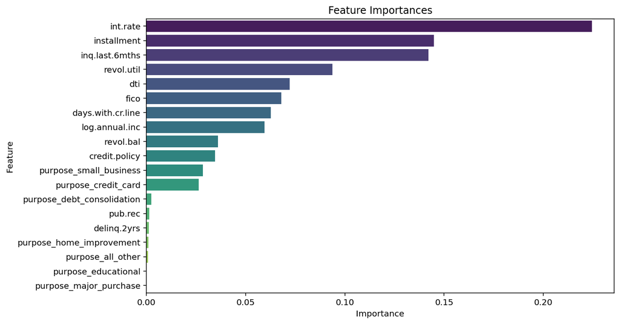

```python
import matplotlib.pyplot as plt
import seaborn as sns

# Get the feature names and importances from the best model
feature_names = X.columns.tolist()
feature_importances = best_clf.feature_importances_

# Ensure that the lengths of both arrays are the same
if len(feature_names) != len(feature_importances):
    raise ValueError("The number of feature names and feature importances must be the same.")

# Create a DataFrame for visualization
importance_df = pd.DataFrame({'Feature': feature_names, 'Importance': feature_importances})

# Sort the DataFrame by feature importance
importance_df = importance_df.sort_values(by='Importance', ascending=False)

# Plot the feature importances
plt.figure(figsize=(10, 6))
sns.barplot(x='Importance', y='Feature', data=importance_df, palette='viridis')
plt.title('Feature Importances')
plt.xlabel('Importance')
plt.ylabel('Feature')
plt.show()
```